# PredicaoEleicao

Thales Souto

11 de dezembro de 2017

```r
library(caret)
library(dplyr)
library(tidyr)
library(magrittr)
library(corrplot)
```

## Pré-Lab

Antes de começar as tarefas, decidi fazer alguns “ajustes” antes. Antes de mais nada vamos carregar o data frame que iremos trabalhar.

```r
options(scipen = 4)
eleicoes <- read.csv("eleicoes2014.csv", encoding="latin1")
```

Nesta parte julguei necessário substituir os valores dados como *NA* pela mediana da coluna.

```r
eleicoes$recursos_de_outros_candidatos.comites[is.na(eleicoes$recursos_de_outros_candidatos.comites)]<-median (eleicoes$recursos_de_outros_candidatos.comites, na.rm = TRUE)
eleicoes$recursos_proprios[is.na(eleicoes$recursos_proprios)]<-median (eleicoes$recursos_proprios, na.rm = TRUE)
eleicoes$recursos_de_pessoas_físicas[is.na(eleicoes$recursos_de_pessoas_físicas)]<-median (eleicoes$recursos_de_pessoas_físicas, na.rm = TRUE)
eleicoes$recursos_de_pessoas_juridicas[is.na(eleicoes$recursos_de_pessoas_juridicas)]<-median (eleicoes$recursos_de_pessoas_juridicas, na.rm = TRUE)
eleicoes$recursos_de_partidos[is.na(eleicoes$recursos_de_partidos)]<-median (eleicoes$recursos_de_partidos, na.rm = TRUE)
```

Feito isso, criei um novo data frame chamado filtra_dados que receberá o data frame *eleicoes* menos variáveis que não influenciam no número de votos, são essas: Nome, Sequencial do Candidato, Número do Candidato, Cargo, Setor Economico Receita e Setor Economico Despesa.

```r
filtra_dados <- eleicoes %>% select(-nome, -sequencial_candidato, -numero_cadidato, -cargo, -setor_economico_receita, -setor_economico_despesa)
```

Bom, após esses ajustes podemos começar as nossas tarefas.

## 1. Usando todas as variáveis disponíveis, tune (usando validação cruzada): (i) um modelo de regressão Ridge, (ii) um modelo de regressão Lasso e (iii) um modelo KNN. Para os modelos de regressão linear, o parâmetro a ser tunado é o lambda (penalização dos coeficientes) e o KNN o número de vizinhos.

É interessante criar uma variável de controle de treino.

```r
fitControl <- trainControl(method='cv', number = 10)
```

fitControl é a nossa variável de controle para validação cruzada. É importante que tunemos o lambda no modelo Ridge:

```r
lambda.grid <- expand.grid(lambda = seq(0, 0.20, by=0.01))
ridge.fit <- train(votos ~ ., data=filtra_dados,
                  method='ridge',
                  metric="RMSE",
                  tuneGrid = lambda.grid,
                  trControl=fitControl)
ridge.fit
```

```
Ridge Regression

4152 samples
  19 predictor

No pre-processing
Resampling: Cross-Validated (10 fold)
Summary of sample sizes: 3737, 3737, 3738, 3736, 3737, 3736, ...
Resampling results across tuning parameters:

  lambda  RMSE      Rsquared   MAE
  0.00    31425.03  0.5213040  13102.15
  0.01    31533.08  0.5153907  12921.80
  0.02    31464.69  0.5166479  12933.64
  0.03    31430.20  0.5175819  12948.50
  0.04    31416.06  0.5182939  12966.71
  0.05    31414.69  0.5188721  12985.71
  0.06    31421.94  0.5193686  13003.24
  0.07    31435.40  0.5198135  13021.34
  0.08    31453.64  0.5202242  13039.62
  0.09    31475.74  0.5206112  13057.75
  0.10    31501.13  0.5209805  13076.84
  0.11    31529.40  0.5213361  13096.90
  0.12    31560.28  0.5216803  13117.56
  0.13    31593.56  0.5220145  13139.00
  0.14    31629.11  0.5223398  13161.16
  0.15    31666.80  0.5226568  13183.99
  0.16    31706.54  0.5229660  13208.65
  0.17    31748.27  0.5232676  13234.51
  0.18    31791.91  0.5235619  13261.82
  0.19    31837.41  0.5238490  13290.78
  0.20    31884.73  0.5241292  13320.96

RMSE was used to select the optimal model using  the smallest value.
The final value used for the model was lambda = 0.05.
```

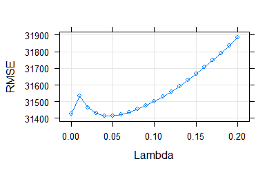

```r
plot(ridge.fit, xlab = "Lambda", ylab = "RMSE")
```

```r
ridge.fit
```

```
Ridge Regression

4152 samples
  19 predictor

No pre-processing
Resampling: Cross-Validated (10 fold)
Summary of sample sizes: 3737, 3737, 3738, 3736, 3737, 3736, ...
Resampling results across tuning parameters:

  lambda  RMSE      Rsquared   MAE
  0.00    31425.03  0.5213040  13102.15
  0.01    31533.08  0.5153907  12921.80
  0.02    31464.69  0.5166479  12933.64
  0.03    31430.20  0.5175819  12948.50
  0.04    31416.06  0.5182939  12966.71
  0.05    31414.69  0.5188721  12985.71
  0.06    31421.94  0.5193686  13003.24
  0.07    31435.40  0.5198135  13021.34
  0.08    31453.64  0.5202242  13039.62
  0.09    31475.74  0.5206112  13057.75
  0.10    31501.13  0.5209805  13076.84
  0.11    31529.40  0.5213361  13096.90
  0.12    31560.28  0.5216803  13117.56
  0.13    31593.56  0.5220145  13139.00
  0.14    31629.11  0.5223398  13161.16
  0.15    31666.80  0.5226568  13183.99
  0.16    31706.54  0.5229660  13208.65
  0.17    31748.27  0.5232676  13234.51
  0.18    31791.91  0.5235619  13261.82
  0.19    31837.41  0.5238490  13290.78
  0.20    31884.73  0.5241292  13320.96

RMSE was used to select the optimal model using  the smallest value.
The final value used for the model was lambda = 0.05.
```

Depois de treinarmos o modelo Ridge tunando o lambda, faremos o mesmo para o modelo Lasso:

```r
fraction.grid <- expand.grid(fraction = seq(0, 0.20, by=0.01))
lasso.fit <- train(votos ~ ., data=filtra_dados,
                  method='lasso',
                  metric="RMSE",
                  tuneGrid = fraction.grid,
                  trControl=fitControl)
```

```
There were missing values in resampled performance measures.
```

```r
lasso.fit
```

```
The lasso

4152 samples
  19 predictor

No pre-processing
Resampling: Cross-Validated (10 fold)
Summary of sample sizes: 3738, 3738, 3737, 3736, 3737, 3736, ...
Resampling results across tuning parameters:

  fraction  RMSE      Rsquared   MAE
  0.00      43177.57        NaN  23677.03
  0.01      38996.62  0.4664427  20428.51
  0.02      35655.03  0.4658600  17571.04
  0.03      33825.70  0.4703260  15769.56
  0.04      32784.34  0.4792135  14373.65
  0.05      32144.20  0.4860934  13200.79
  0.06      31961.29  0.4904921  12383.56
  0.07      31976.16  0.4927504  12126.43
  0.08      31954.70  0.4952639  12137.91
  0.09      31891.40  0.4979698  12143.92
  0.10      31838.19  0.5003044  12167.85
  0.11      31804.83  0.5021240  12228.40
  0.12      31797.02  0.5032867  12312.43
  0.13      31821.13  0.5036555  12410.85
  0.14      31864.47  0.5034843  12527.30
  0.15      31924.31  0.5028365  12640.30
  0.16      31982.08  0.5022684  12700.38
  0.17      32029.32  0.5019785  12734.26
  0.18      32075.44  0.5017154  12768.25
  0.19      32092.15  0.5016883  12790.76
  0.20      32096.63  0.5018038  12809.66

RMSE was used to select the optimal model using  the smallest value.
The final value used for the model was fraction = 0.12.
```

Podemos observar que a fração usada no modelo é 0.12, que é onde encontramos o menor RMSE:

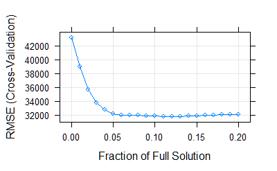

```r
plot(lasso.fit)
```

```r
lasso.fit
```

```
The lasso

4152 samples
  19 predictor

No pre-processing
Resampling: Cross-Validated (10 fold)
Summary of sample sizes: 3738, 3738, 3737, 3736, 3737, 3736, ...
Resampling results across tuning parameters:

  fraction  RMSE      Rsquared   MAE
  0.00      43177.57        NaN  23677.03
  0.01      38996.62  0.4664427  20428.51
  0.02      35655.03  0.4658600  17571.04
  0.03      33825.70  0.4703260  15769.56
  0.04      32784.34  0.4792135  14373.65
  0.05      32144.20  0.4860934  13200.79
  0.06      31961.29  0.4904921  12383.56
  0.07      31976.16  0.4927504  12126.43
  0.08      31954.70  0.4952639  12137.91
  0.09      31891.40  0.4979698  12143.92
  0.10      31838.19  0.5003044  12167.85
  0.11      31804.83  0.5021240  12228.40
  0.12      31797.02  0.5032867  12312.43
  0.13      31821.13  0.5036555  12410.85
  0.14      31864.47  0.5034843  12527.30
  0.15      31924.31  0.5028365  12640.30
  0.16      31982.08  0.5022684  12700.38
  0.17      32029.32  0.5019785  12734.26
  0.18      32075.44  0.5017154  12768.25
  0.19      32092.15  0.5016883  12790.76
  0.20      32096.63  0.5018038  12809.66

RMSE was used to select the optimal model using  the smallest value.
The final value used for the model was fraction = 0.12.
```

Para finalizarmos essa fase de tunar os modelos, vamos treinar um modelo KNN:

```r
knn.grid <- expand.grid(k = seq(1, 100, length=100))
knn.fit <- train(votos ~ ., data=filtra_dados,
                  method='knn',
                  metric="RMSE",
                  tuneGrid = knn.grid,
                  trControl=fitControl)
knn.fit
```

```
k-Nearest Neighbors

4152 samples
  19 predictor

No pre-processing
Resampling: Cross-Validated (10 fold)
Summary of sample sizes: 3738, 3738, 3736, 3736, 3736, 3737, ...
Resampling results across tuning parameters:

  k    RMSE      Rsquared   MAE
    1  37650.02  0.3980780  12839.383
    2  33761.81  0.4570577  11708.677
    3  33299.76  0.4756439  11108.407
    4  32576.24  0.4896525  10877.047
```

[output cut: 99 more lines]

O modelo foi treinado até k = 100, e o k que encontrou o menor valor de RMSE é k = 73.

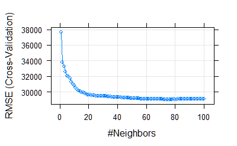

```r
plot(knn.fit)
```

```r
knn.fit
```

```
k-Nearest Neighbors

4152 samples
  19 predictor

No pre-processing
Resampling: Cross-Validated (10 fold)
Summary of sample sizes: 3738, 3738, 3736, 3736, 3736, 3737, ...
Resampling results across tuning parameters:

  k    RMSE      Rsquared   MAE
    1  37650.02  0.3980780  12839.383
    2  33761.81  0.4570577  11708.677
    3  33299.76  0.4756439  11108.407
    4  32576.24  0.4896525  10877.047
```

[output cut: 99 more lines]

## 2. Compare os três modelos em termos do erro RMSE de validação cruzada.

```r
ridge.pred <- predict(ridge.fit, filtra_dados %>% select(-votos))
ridge.df <- data.frame(pred = ridge.pred, obs = filtra_dados$votos)
ridge.df$model <- "Ridge"
ridge.round <- round(defaultSummary(ridge.df), digits = 3)
ridge.round
```

```
    RMSE Rsquared      MAE
32358.91     0.49 12534.88
```

```r
lasso.pred <- predict(lasso.fit, filtra_dados %>% select(-votos))
lasso.df <- data.frame(pred = lasso.pred, obs = filtra_dados$votos)
lasso.df$model <- "Lasso"
lasso.round <- round(defaultSummary(lasso.df), digits = 3)
lasso.round
```

```
     RMSE  Rsquared       MAE
32382.437     0.489 11889.996
```

```r
knn.pred <- predict(knn.fit, filtra_dados %>% select(-votos))
knn.df <- data.frame(pred = knn.pred, obs = filtra_dados$votos)
knn.df$model <- "KNN"
knn.round <- round(defaultSummary(knn.df), digits = 3)
knn.round
```

```
     RMSE  Rsquared       MAE
32384.631     0.490  9575.794
```

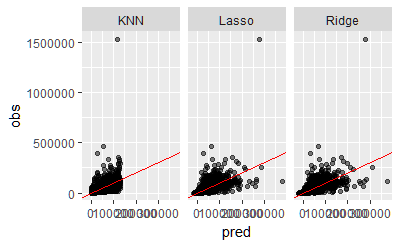

```r
comparacao <- rbind(ridge.df, lasso.df, knn.df)
ggplot(comparacao, aes(x = pred, y = obs)) +
  geom_point(alpha = 0.5, position = position_jitter(width=0.2)) +
  facet_grid(. ~ model) +
  geom_abline(color="red")
```

## 3. Quais as variáveis mais importantes segundo o modelo de regressão Ridge e Lasso? Variáveis foram descartadas pelo Lasso? Quais?

```r
varImp(ridge.fit)
```

```
loess r-squared variable importance

                                        Overall
total_receita                         100.00000
total_despesa                          97.96543
recursos_de_pessoas_juridicas          71.52165
quantidade_despesas                    63.66857
recursos_de_pessoas_físicas            54.70236
recursos_de_partidos                   49.88189
quantidade_doacoes                     49.13733
quantidade_fornecedores                44.33473
media_receita                          40.29484
quantidade_doadores                    37.85684
recursos_de_outros_candidatos.comites  27.08317
media_despesa                          23.31508
sexo                                    5.11687
grau                                    4.06040
estado_civil                            2.95494
idade                                   1.88118
partido                                 0.26099
UF                                      0.01866
recursos_proprios                       0.00000
```

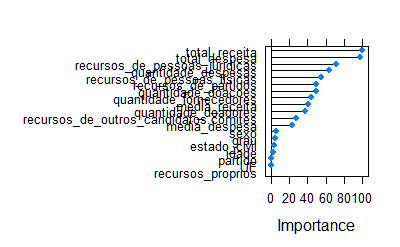

```r
plot(varImp(ridge.fit))
```

O modelo lasso define uma importância para uma variável de acordo com “a dificuldade” (maior lâmbda) para “zerar”/desconsiderar tal variável do modelo associando um valor de [0, 100] a essa variável, quanto maior mais importante a variável é para o modelo.

```r
varImp(lasso.fit)
```

```
loess r-squared variable importance

                                        Overall
total_receita                         100.00000
total_despesa                          97.96543
recursos_de_pessoas_juridicas          71.52165
quantidade_despesas                    63.66857
recursos_de_pessoas_físicas            54.70236
recursos_de_partidos                   49.88189
quantidade_doacoes                     49.13733
quantidade_fornecedores                44.33473
media_receita                          40.29484
quantidade_doadores                    37.85684
recursos_de_outros_candidatos.comites  27.08317
media_despesa                          23.31508
sexo                                    5.11687
grau                                    4.06040
estado_civil                            2.95494
idade                                   1.88118
partido                                 0.26099
UF                                      0.01866
recursos_proprios                       0.00000
```

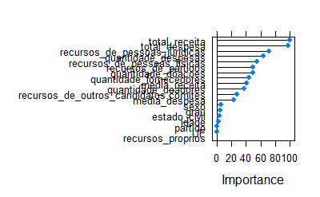

```r
plot(varImp(lasso.fit))
```

recursos_próprios é sem dúvida a variável menos importante seguida por UF e Partido, as próximas variáveis têm um nível de importância relativamente próximo, onde se destacam pelo nível de importância total_receita e total_despesa que são consideras extremamente importantes para o modelo (~100).

Além disso a variável retirada do modelo foi recursos_proprios.

## 4. Re-treine o melhor modelo (usando os melhores valores de parâmetros encontrados em todos os dados, sem usar validação cruzada).

```r
knn.new.grid <- expand.grid(k = 73)
knn.no.cv <- train(votos ~ ., data = filtra_dados,
               method='knn',
               tuneGrid = knn.new.grid)
knn.no.cv
```

```
k-Nearest Neighbors

4152 samples
  19 predictor

No pre-processing
Resampling: Bootstrapped (25 reps)
Summary of sample sizes: 4152, 4152, 4152, 4152, 4152, 4152, ...
Resampling results:

  RMSE      Rsquared   MAE
  32800.39  0.5003535  9832.639

Tuning parameter 'k' was held constant at a value of 73
```

```r
knn.new.pred <- predict(knn.no.cv, filtra_dados %>% select(-votos))
knn.new.df <- data.frame(pred = knn.new.pred, obs = filtra_dados$votos)
knn.new.df$model <- "KNN sem CV"
knn.new.round <- round(defaultSummary(knn.new.df), digits = 3)
knn.new.round
```

```
     RMSE  Rsquared       MAE
32384.631     0.490  9575.794
```

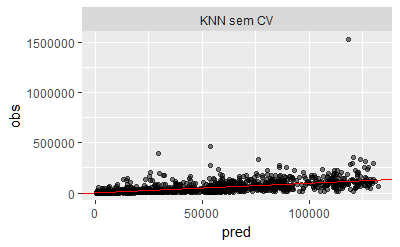

```r
ggplot(knn.new.df, aes(x = pred, y = obs)) +
  geom_point(alpha = 0.5, position = position_jitter(width=0.2)) +
  facet_grid(. ~ model) +
  geom_abline(color="red")
```

## 5. Use esse último modelo treinado para prever os dados de teste disponíveis no challenge que criamos na plataforma Kaggle.

```r
kaggle_treino <- read.csv("train.csv", encoding="UTF-8")
kaggle_treino <- kaggle_treino %>% select(-nome, -numero_cadidato, -cargo, -setor_economico_receita, -setor_economico_despesa)
```

```r
kaggle_teste <- read.csv("test.csv", encoding="UTF-8")
kaggle_teste <- kaggle_teste %>% select(-nome, -numero_cadidato, -cargo, -setor_economico_receita, -setor_economico_despesa)
```

```r
kaggle_treino[is.na(kaggle_treino)] <- 0
kaggle_teste[is.na(kaggle_teste)] <- 0
kaggle.knn <- train(votos ~ ., data=kaggle_treino,
                   method='knn',
                   tuneGrid = knn.new.grid)
kaggle.knn
```

```
k-Nearest Neighbors

4152 samples
  20 predictor

No pre-processing
Resampling: Bootstrapped (25 reps)
Summary of sample sizes: 4152, 4152, 4152, 4152, 4152, 4152, ...
Resampling results:

  RMSE      Rsquared   MAE
  40003.81  0.3621762  13260.08

Tuning parameter 'k' was held constant at a value of 73
```

```r
predicao.kaggle <- predict(knn.no.cv, kaggle_teste)
kaggle_teste$votos <- predicao.kaggle
kaggle_teste <- kaggle_teste %>% select(ID, votos)
```

```r
write.csv(kaggle_teste, file = "kaggle_knn.csv", row.names = FALSE)
```